# Tugas Pertemuan 4

Gemala Aleida FItri G1401231070

2025-09-25

## White Noise

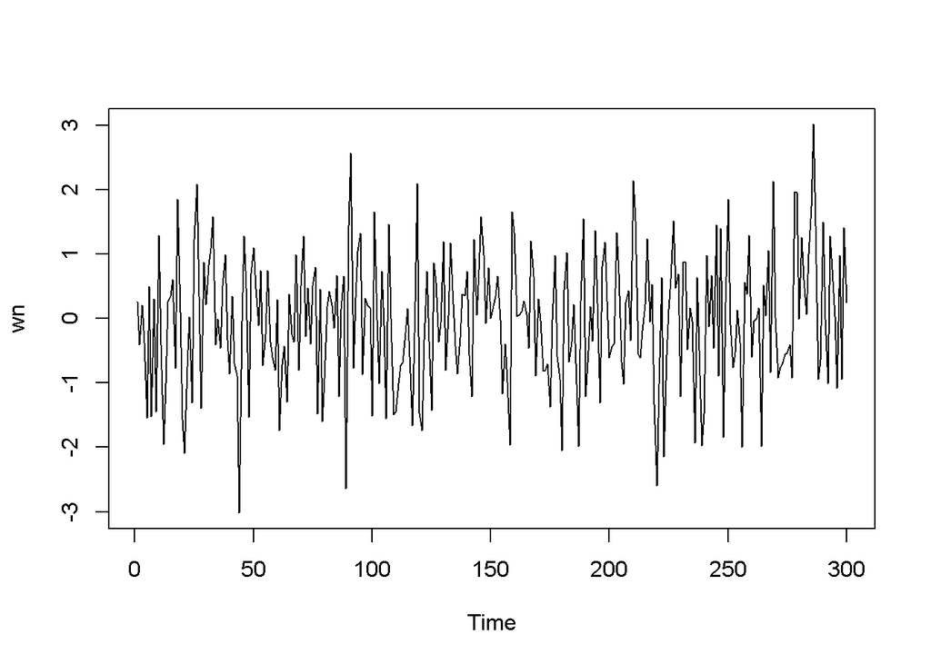

```r
set.seed(1070)
wn <- rnorm(300)
ts.plot(wn)
```

## Proses MA

$$y_{t} = c + e_t + \theta_{1}e_{t-1} + \theta_{2}e_{t-2} + \dots +
\theta_{q}e_{t-q} = c+{e_t+\sum_{i=1}^p \theta_ie_{t-i}}$$

## Pembangkitan Proses MA(2)

```r
set.seed(1070)
ma <- numeric(300)
ma[1] <- wn[1]
ma[2] <- wn[2] + 0.4*wn[1]
```

$$y_t = e_t+0.4e_{t-1}+0.6e_{t-2}$$

```r
for(i in 3:300){
   ma[i] <- wn[i] + 0.4 * wn[i - 1] + 0.6 * wn[i-2]
}
ma
```

```
##   [1]  0.2537464871 -0.3005009164  0.1977782451 -0.5380170695 -1.5706315393
##   [6] -0.3450559932 -2.2495651083 -0.0049331364 -2.2350094673  0.8950042425
##  [11] -0.7584774614 -1.3431680812 -2.0390968024 -1.3173976721 -0.1623828538
##  [16]  0.8999069005 -0.3199077284  1.8995113823  0.3713831406 -0.4257374195
##  [21] -2.6644368533 -2.5332837577 -1.5372752883 -1.7539635846  0.7149611036
##  [26]  1.7926744134  1.9156025671  0.0005712698  0.5258500448 -0.2666457869
##  [31]  1.4435274412  1.5435602636  2.5125626941  0.8768852783  0.7798003132
##  [36] -0.7038620441  0.3198658591  0.9190235785  0.3682788038 -0.3939292368
##  [41] -0.1984487432 -1.0676779046 -0.9595554276 -3.7869708674 -1.7826290259
##  [46] -0.5432193276  0.9622381901 -0.5754972588  0.3712756568  0.4599343247
##  [51]  1.3241811002  0.7377347789  0.9788223122 -0.5001428475 -0.0902670638
##  [56]  0.2095098447 -0.2070612249 -0.2960489097 -1.2597274960 -0.3914040757
##  [61] -2.0986693448 -1.2339419101 -1.7515743030 -1.8920227190 -0.3946764621
##  [66] -0.8693979116 -0.2329353488  0.6948332518 -0.6236541326  0.7811210007
##  [71]  0.9979433991  0.5336062407  1.1271468175 -0.3758871070  0.6328183508
```

[output cut: 45 more lines]

```r
ma2 <- arima.sim(list(order=c(0,0,2), ma=c(0.4,0.6)), n=300)
ma2
```

```
## Time Series:
## Start = 1
## End = 300
## Frequency = 1
##   [1]  0.1977782451 -0.5380170695 -1.5706315393 -0.3450559932 -2.2495651083
##   [6] -0.0049331364 -2.2350094673  0.8950042425 -0.7584774614 -1.3431680812
##  [11] -2.0390968024 -1.3173976721 -0.1623828538  0.8999069005 -0.3199077284
##  [16]  1.8995113823  0.3713831406 -0.4257374195 -2.6644368533 -2.5332837577
##  [21] -1.5372752883 -1.7539635846  0.7149611036  1.7926744134  1.9156025671
##  [26]  0.0005712698  0.5258500448 -0.2666457869  1.4435274412  1.5435602636
##  [31]  2.5125626941  0.8768852783  0.7798003132 -0.7038620441  0.3198658591
##  [36]  0.9190235785  0.3682788038 -0.3939292368 -0.1984487432 -1.0676779046
##  [41] -0.9595554276 -3.7869708674 -1.7826290259 -0.5432193276  0.9622381901
##  [46] -0.5754972588  0.3712756568  0.4599343247  1.3241811002  0.7377347789
##  [51]  0.9788223122 -0.5001428475 -0.0902670638  0.2095098447 -0.2070612249
```

[output cut: 49 more lines]

## Karakteristik MA(2)

### Plot Time Series

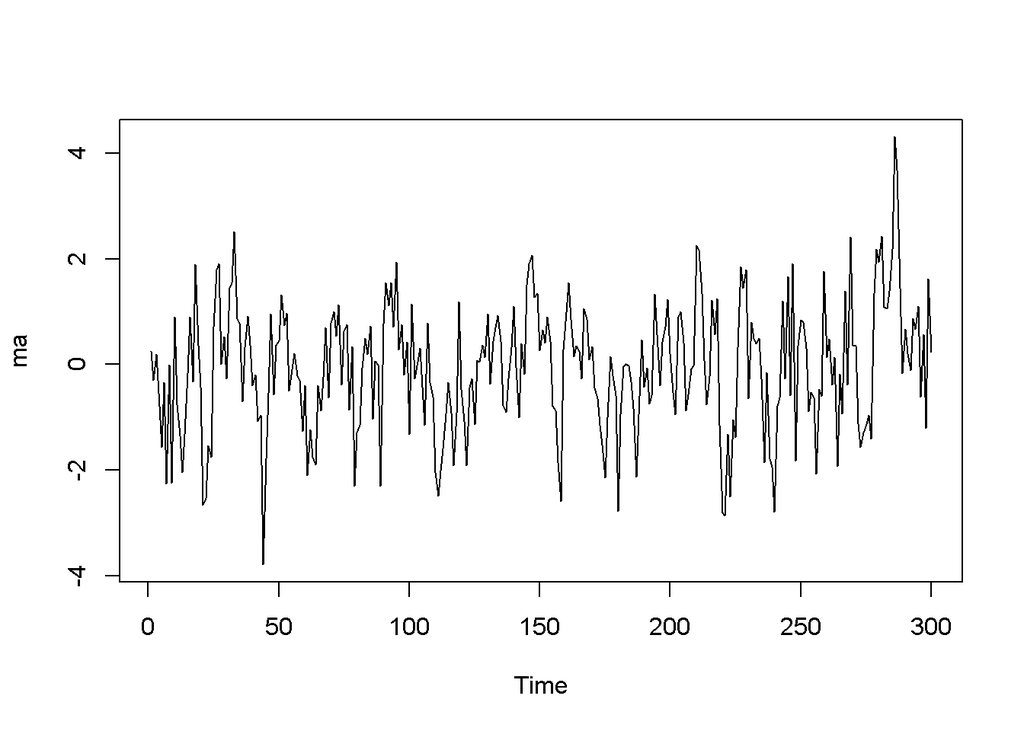

```r
ts.plot(ma)
```

Berdasarkan plot time series, terlihat bahwa data MA(2) yang dibangkitkan stasioner dalam rataan

### Plot ACF

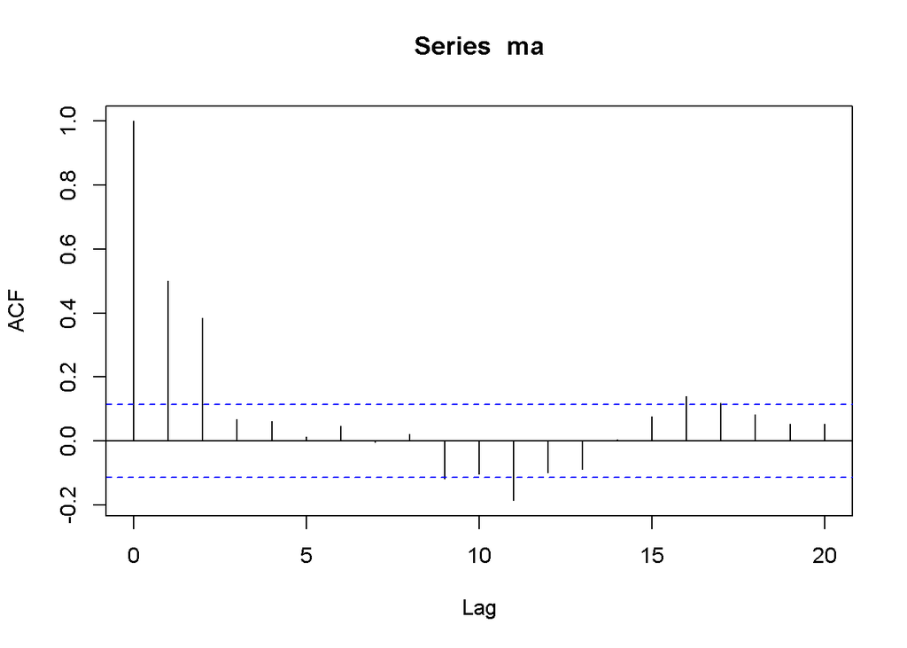

```r
acf(ma,lag.max = 20)
```

Plot ACF *cuts off* di lag kedua

### Plot PACF

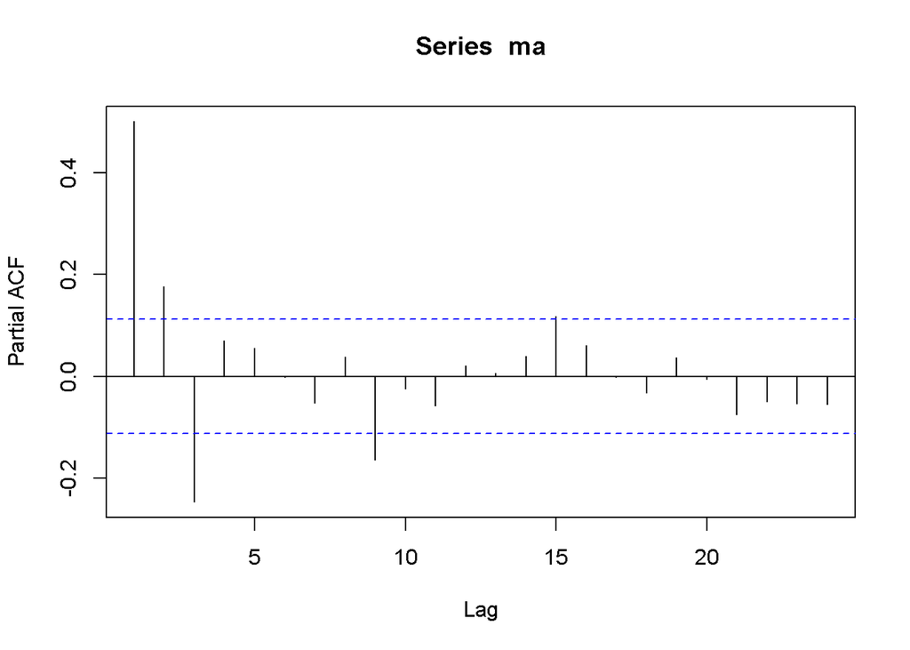

```r
pacf(ma)
```

Plot PACF cenderung *tails off* dan membentuk gelombang sinus

### Plot EACF

```r
TSA::eacf(ma)
```

```
## AR/MA
##   0 1 2 3 4 5 6 7 8 9 10 11 12 13
## 0 x x o o o o o o o o x  o  o  o
## 1 x x x o o o o o x o x  o  o  o
## 2 x x o x o o o o o o x  o  o  o
## 3 x x o x o o o o o o o  o  o  o
## 4 x x x o o o o o o o o  o  o  o
## 5 o x x o o o o o o o o  o  o  o
## 6 o x x o o o o x o o o  o  o  o
## 7 x x o o x x o x o o o  o  o  o
```

Berdasarkan pola segitiga nol pada plot EACF, segitiga nol pertama berada pada ordo AR(0) dan ordo MA(2)

### Scatterplot Antar Lag

#### Korelasi antara $Y_t$ dengan $Y_{t-1}$

```r
#Yt
yt_ma <- ma[-1]
yt_ma
```

```
##   [1] -0.3005009164  0.1977782451 -0.5380170695 -1.5706315393 -0.3450559932
##   [6] -2.2495651083 -0.0049331364 -2.2350094673  0.8950042425 -0.7584774614
##  [11] -1.3431680812 -2.0390968024 -1.3173976721 -0.1623828538  0.8999069005
##  [16] -0.3199077284  1.8995113823  0.3713831406 -0.4257374195 -2.6644368533
##  [21] -2.5332837577 -1.5372752883 -1.7539635846  0.7149611036  1.7926744134
##  [26]  1.9156025671  0.0005712698  0.5258500448 -0.2666457869  1.4435274412
##  [31]  1.5435602636  2.5125626941  0.8768852783  0.7798003132 -0.7038620441
##  [36]  0.3198658591  0.9190235785  0.3682788038 -0.3939292368 -0.1984487432
##  [41] -1.0676779046 -0.9595554276 -3.7869708674 -1.7826290259 -0.5432193276
##  [46]  0.9622381901 -0.5754972588  0.3712756568  0.4599343247  1.3241811002
##  [51]  0.7377347789  0.9788223122 -0.5001428475 -0.0902670638  0.2095098447
##  [56] -0.2070612249 -0.2960489097 -1.2597274960 -0.3914040757 -2.0986693448
##  [61] -1.2339419101 -1.7515743030 -1.8920227190 -0.3946764621 -0.8693979116
##  [66] -0.2329353488  0.6948332518 -0.6236541326  0.7811210007  0.9979433991
##  [71]  0.5336062407  1.1271468175 -0.3758871070  0.6328183508  0.7592105044
```

[output cut: 45 more lines]

```r
#Yt-1
yt_1_ma <- ma[-300]
yt_1_ma
```

```
##   [1]  0.2537464871 -0.3005009164  0.1977782451 -0.5380170695 -1.5706315393
##   [6] -0.3450559932 -2.2495651083 -0.0049331364 -2.2350094673  0.8950042425
##  [11] -0.7584774614 -1.3431680812 -2.0390968024 -1.3173976721 -0.1623828538
##  [16]  0.8999069005 -0.3199077284  1.8995113823  0.3713831406 -0.4257374195
##  [21] -2.6644368533 -2.5332837577 -1.5372752883 -1.7539635846  0.7149611036
##  [26]  1.7926744134  1.9156025671  0.0005712698  0.5258500448 -0.2666457869
##  [31]  1.4435274412  1.5435602636  2.5125626941  0.8768852783  0.7798003132
##  [36] -0.7038620441  0.3198658591  0.9190235785  0.3682788038 -0.3939292368
##  [41] -0.1984487432 -1.0676779046 -0.9595554276 -3.7869708674 -1.7826290259
##  [46] -0.5432193276  0.9622381901 -0.5754972588  0.3712756568  0.4599343247
##  [51]  1.3241811002  0.7377347789  0.9788223122 -0.5001428475 -0.0902670638
##  [56]  0.2095098447 -0.2070612249 -0.2960489097 -1.2597274960 -0.3914040757
##  [61] -2.0986693448 -1.2339419101 -1.7515743030 -1.8920227190 -0.3946764621
##  [66] -0.8693979116 -0.2329353488  0.6948332518 -0.6236541326  0.7811210007
##  [71]  0.9979433991  0.5336062407  1.1271468175 -0.3758871070  0.6328183508
```

[output cut: 45 more lines]

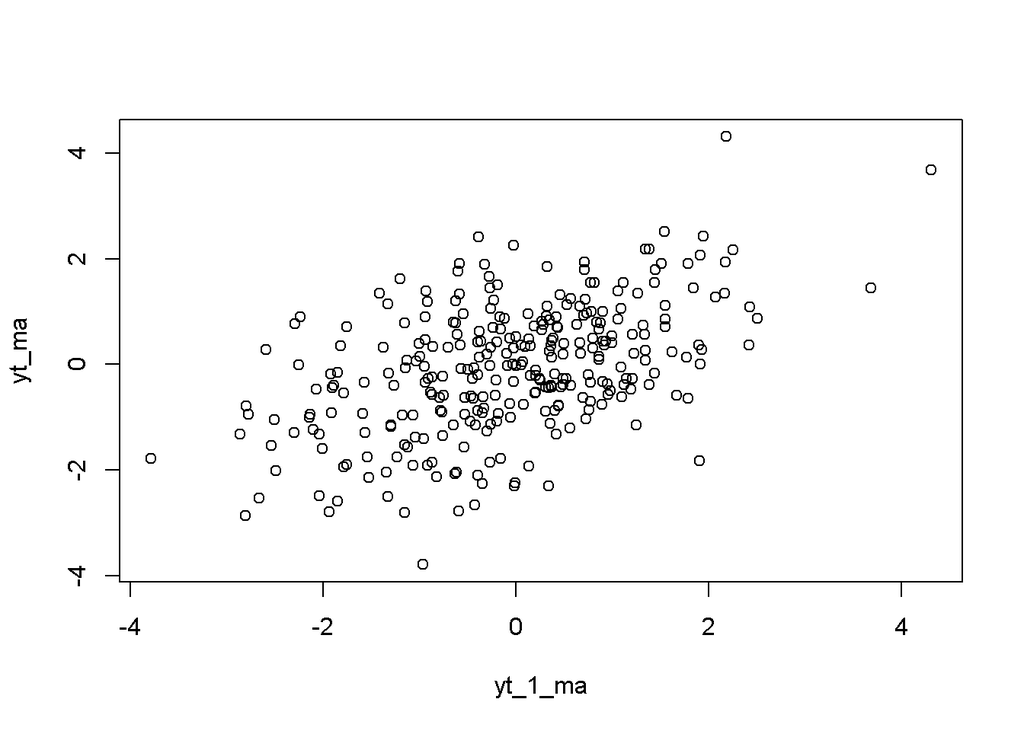

```r
plot(y=yt_ma,x=yt_1_ma)
```

Berdasarkan scatterplot tersebut, terlihat bahwa terdapat hubungan positif antara $Y_t$ dengan $Y_{t-1}$

```r
cor(yt_ma,yt_1_ma)
```

```
## [1] 0.5012209
```

Korelasi antara $Y_t$ dengan $Y_{t-1}$ dari hasil simulasi mendekati perhitungan teoritis yaitu

$$\rho_1=\frac{-\theta_1 +
\theta_1\theta_2}{1+(-\theta_1)^2+(-\theta_2)^2}=\frac{-(-0.4)+(-0.4)(-0.6)}{1+(-0.4)^2+(-0.6)^2}=0.42$$

#### Korelasi antara $Y_t$ dengan $Y_{t-2}$

```r
#Yt
yt_ma2 <- ma[-c(1,2)]
yt_ma2
```

```
##   [1]  0.1977782451 -0.5380170695 -1.5706315393 -0.3450559932 -2.2495651083
##   [6] -0.0049331364 -2.2350094673  0.8950042425 -0.7584774614 -1.3431680812
##  [11] -2.0390968024 -1.3173976721 -0.1623828538  0.8999069005 -0.3199077284
##  [16]  1.8995113823  0.3713831406 -0.4257374195 -2.6644368533 -2.5332837577
##  [21] -1.5372752883 -1.7539635846  0.7149611036  1.7926744134  1.9156025671
##  [26]  0.0005712698  0.5258500448 -0.2666457869  1.4435274412  1.5435602636
##  [31]  2.5125626941  0.8768852783  0.7798003132 -0.7038620441  0.3198658591
##  [36]  0.9190235785  0.3682788038 -0.3939292368 -0.1984487432 -1.0676779046
##  [41] -0.9595554276 -3.7869708674 -1.7826290259 -0.5432193276  0.9622381901
##  [46] -0.5754972588  0.3712756568  0.4599343247  1.3241811002  0.7377347789
##  [51]  0.9788223122 -0.5001428475 -0.0902670638  0.2095098447 -0.2070612249
##  [56] -0.2960489097 -1.2597274960 -0.3914040757 -2.0986693448 -1.2339419101
##  [61] -1.7515743030 -1.8920227190 -0.3946764621 -0.8693979116 -0.2329353488
##  [66]  0.6948332518 -0.6236541326  0.7811210007  0.9979433991  0.5336062407
##  [71]  1.1271468175 -0.3758871070  0.6328183508  0.7592105044 -0.8604613553
```

[output cut: 45 more lines]

```r
#Yt-2
yt_2_ma <- ma[-c(299,300)]
yt_2_ma
```

```
##   [1]  0.2537464871 -0.3005009164  0.1977782451 -0.5380170695 -1.5706315393
##   [6] -0.3450559932 -2.2495651083 -0.0049331364 -2.2350094673  0.8950042425
##  [11] -0.7584774614 -1.3431680812 -2.0390968024 -1.3173976721 -0.1623828538
##  [16]  0.8999069005 -0.3199077284  1.8995113823  0.3713831406 -0.4257374195
##  [21] -2.6644368533 -2.5332837577 -1.5372752883 -1.7539635846  0.7149611036
##  [26]  1.7926744134  1.9156025671  0.0005712698  0.5258500448 -0.2666457869
##  [31]  1.4435274412  1.5435602636  2.5125626941  0.8768852783  0.7798003132
##  [36] -0.7038620441  0.3198658591  0.9190235785  0.3682788038 -0.3939292368
##  [41] -0.1984487432 -1.0676779046 -0.9595554276 -3.7869708674 -1.7826290259
##  [46] -0.5432193276  0.9622381901 -0.5754972588  0.3712756568  0.4599343247
##  [51]  1.3241811002  0.7377347789  0.9788223122 -0.5001428475 -0.0902670638
##  [56]  0.2095098447 -0.2070612249 -0.2960489097 -1.2597274960 -0.3914040757
##  [61] -2.0986693448 -1.2339419101 -1.7515743030 -1.8920227190 -0.3946764621
##  [66] -0.8693979116 -0.2329353488  0.6948332518 -0.6236541326  0.7811210007
##  [71]  0.9979433991  0.5336062407  1.1271468175 -0.3758871070  0.6328183508
```

[output cut: 45 more lines]

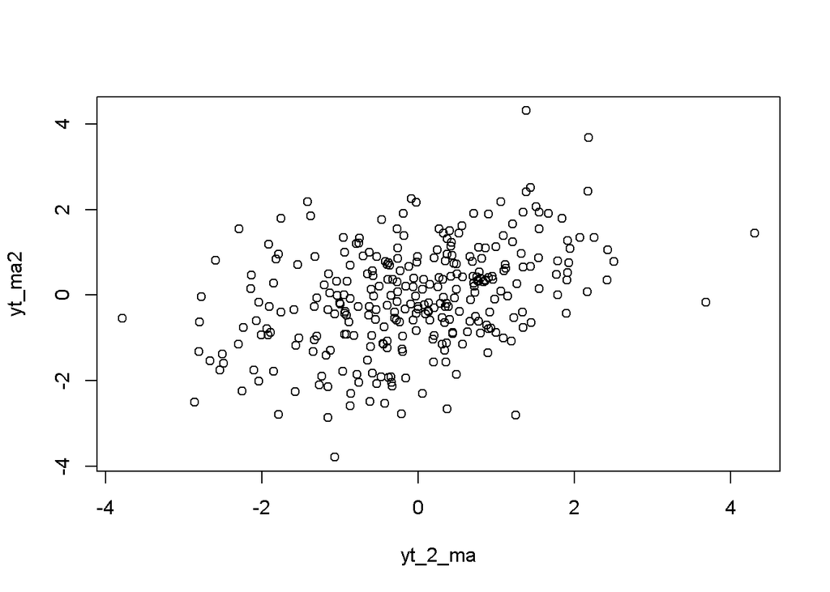

```r
plot(y=yt_ma2,x=yt_2_ma)
```

Berdasarkan scatterplot tersebut, terlihat bahwa terdapat hubungan positif antara $Y_t$ dengan $Y_{t-2}$.

```r
cor(yt_ma2,yt_2_ma)
```

```
## [1] 0.3849949
```

Korelasi antara $Y_t$ dengan $Y_{t-2}$ dari hasil simulasi mendekati perhitungan teoritis yaitu

$$\rho_1=\frac{-\theta_2}{1+(-\theta_1)^2+(-\theta_2)^2}=\frac{-(-0.6)}{1+(-0.4)^2+(-0.6)^2}=0.39$$

#### Korelasi antara $Y_t$ dengan $Y_{t-3}$

```r
#Yt
yt_ma3 <- ma[-c(1,2,3)]
yt_ma3
```

```
##   [1] -0.5380170695 -1.5706315393 -0.3450559932 -2.2495651083 -0.0049331364
##   [6] -2.2350094673  0.8950042425 -0.7584774614 -1.3431680812 -2.0390968024
##  [11] -1.3173976721 -0.1623828538  0.8999069005 -0.3199077284  1.8995113823
##  [16]  0.3713831406 -0.4257374195 -2.6644368533 -2.5332837577 -1.5372752883
##  [21] -1.7539635846  0.7149611036  1.7926744134  1.9156025671  0.0005712698
##  [26]  0.5258500448 -0.2666457869  1.4435274412  1.5435602636  2.5125626941
##  [31]  0.8768852783  0.7798003132 -0.7038620441  0.3198658591  0.9190235785
##  [36]  0.3682788038 -0.3939292368 -0.1984487432 -1.0676779046 -0.9595554276
##  [41] -3.7869708674 -1.7826290259 -0.5432193276  0.9622381901 -0.5754972588
##  [46]  0.3712756568  0.4599343247  1.3241811002  0.7377347789  0.9788223122
##  [51] -0.5001428475 -0.0902670638  0.2095098447 -0.2070612249 -0.2960489097
##  [56] -1.2597274960 -0.3914040757 -2.0986693448 -1.2339419101 -1.7515743030
##  [61] -1.8920227190 -0.3946764621 -0.8693979116 -0.2329353488  0.6948332518
##  [66] -0.6236541326  0.7811210007  0.9979433991  0.5336062407  1.1271468175
##  [71] -0.3758871070  0.6328183508  0.7592105044 -0.8604613553  0.3409547419
```

[output cut: 45 more lines]

```r
#Yt-3
yt_3_ma <- ma[-c(298,299,300)]
yt_3_ma
```

```
##   [1]  0.2537464871 -0.3005009164  0.1977782451 -0.5380170695 -1.5706315393
##   [6] -0.3450559932 -2.2495651083 -0.0049331364 -2.2350094673  0.8950042425
##  [11] -0.7584774614 -1.3431680812 -2.0390968024 -1.3173976721 -0.1623828538
##  [16]  0.8999069005 -0.3199077284  1.8995113823  0.3713831406 -0.4257374195
##  [21] -2.6644368533 -2.5332837577 -1.5372752883 -1.7539635846  0.7149611036
##  [26]  1.7926744134  1.9156025671  0.0005712698  0.5258500448 -0.2666457869
##  [31]  1.4435274412  1.5435602636  2.5125626941  0.8768852783  0.7798003132
##  [36] -0.7038620441  0.3198658591  0.9190235785  0.3682788038 -0.3939292368
##  [41] -0.1984487432 -1.0676779046 -0.9595554276 -3.7869708674 -1.7826290259
##  [46] -0.5432193276  0.9622381901 -0.5754972588  0.3712756568  0.4599343247
##  [51]  1.3241811002  0.7377347789  0.9788223122 -0.5001428475 -0.0902670638
##  [56]  0.2095098447 -0.2070612249 -0.2960489097 -1.2597274960 -0.3914040757
##  [61] -2.0986693448 -1.2339419101 -1.7515743030 -1.8920227190 -0.3946764621
##  [66] -0.8693979116 -0.2329353488  0.6948332518 -0.6236541326  0.7811210007
##  [71]  0.9979433991  0.5336062407  1.1271468175 -0.3758871070  0.6328183508
```

[output cut: 45 more lines]

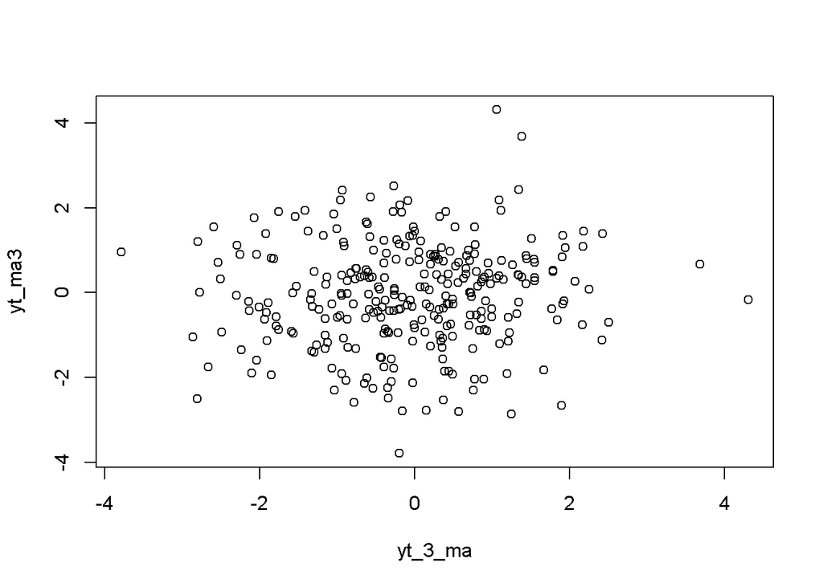

```r
plot(y=yt_ma3,x=yt_3_ma)
```

Berdasarkan scatterplot tersebut, terlihat bahwa cenderung tidak terdapat hubungan antara $Y_t$ dengan $Y_{t-3}$.

```r
cor(yt_ma3,yt_3_ma)
```

```
## [1] 0.06780923
```

## Proses AR

$$y_{t} = c + e_t + \phi_{1}Y_{t-1} +
\phi_{2}Y_{t-2} + \dots + \phi_{q}Y_{t-q} = c+{e_t+\sum_{i=1}^p
\phi_iY_{t-i}}$$

## Pembangkitan Proses AR

```r
set.seed(1070)
```

$$Y_t = e_t+0.5Y_{t-1}+0.2Y_{t-2}$$

```r
n<-length(wn)
n
```

```
## [1] 300
```

```r
ar <- numeric(n)
ar[1] <- wn[1]
ar[2] <- wn[2] + 0.5*ar[1]

for (i in 3:n) {
  ar[i]<-wn[i]+0.5*ar[i-1]+0.2*ar[i-2]
}
ar
```

```
##   [1]  0.253746487 -0.275126268  0.119516321 -0.374616519 -1.706094859
##   [6] -0.428341126 -2.079192568 -0.820454197 -2.268717384 -0.009270767
##  [11] -0.866936764 -2.388574714 -2.380335899 -1.408264782 -0.838832955
##  [16] -0.093480046 -0.982270067  1.332232088  0.564877991 -1.020176269
##  [21] -2.491054293 -2.203832446 -1.579329298 -2.540151809 -0.359571062
##  [26]  1.400142642  0.972753841 -0.623637095  0.757841244  0.471529333
##  [31]  1.218860490  1.784283667  2.717341059  1.311513157  1.191774470
##  [36]  0.399716414  0.945938533  1.543930026  0.628389273 -0.232453702
##  [41]  0.352834066 -0.561844230 -1.099232358 -3.678342756 -2.101777550
##  [46] -0.502858135 -0.197370244 -1.734739256 -0.206023617  0.650936145
##  [51]  0.747594092  0.395849274  1.091521322 -0.107962478 -0.079233561
##  [56]  0.685458999 -0.032711796 -0.479476140 -1.050166358 -0.330700886
##  [61] -2.107832510 -1.835185337 -1.765212634 -2.542167375 -1.246161002
##  [66] -1.376583578 -1.299210625  0.061627639 -1.030290324  0.006876374
##  [71]  1.072202329  0.255336193  0.817218154  0.063029520  0.701369705
```

[output cut: 45 more lines]

```r
ar2 <- arima.sim(list(order=c(2,0,0), ar=c(0.5,0.2)), n=300)
ar2
```

```
## Time Series:
## Start = 1
## End = 300
## Frequency = 1
##   [1]  1.400142642  0.972753841 -0.623637095  0.757841244  0.471529333
##   [6]  1.218860490  1.784283667  2.717341059  1.311513157  1.191774470
##  [11]  0.399716414  0.945938533  1.543930026  0.628389273 -0.232453702
##  [16]  0.352834066 -0.561844230 -1.099232358 -3.678342756 -2.101777550
##  [21] -0.502858135 -0.197370244 -1.734739256 -0.206023617  0.650936145
##  [26]  0.747594092  0.395849274  1.091521322 -0.107962478 -0.079233561
##  [31]  0.685458999 -0.032711796 -0.479476140 -1.050166358 -0.330700886
##  [36] -2.107832510 -1.835185337 -1.765212634 -2.542167375 -1.246161002
##  [41] -1.376583578 -1.299210625  0.061627639 -1.030290324  0.006876374
##  [46]  1.072202329  0.255336193  0.817218154  0.063029520  0.701369705
##  [51]  1.157924813 -0.762925419  0.307161268 -1.593044389 -1.664415781
```

[output cut: 49 more lines]

## Karakteristik AR(2)

### Plot Time Series

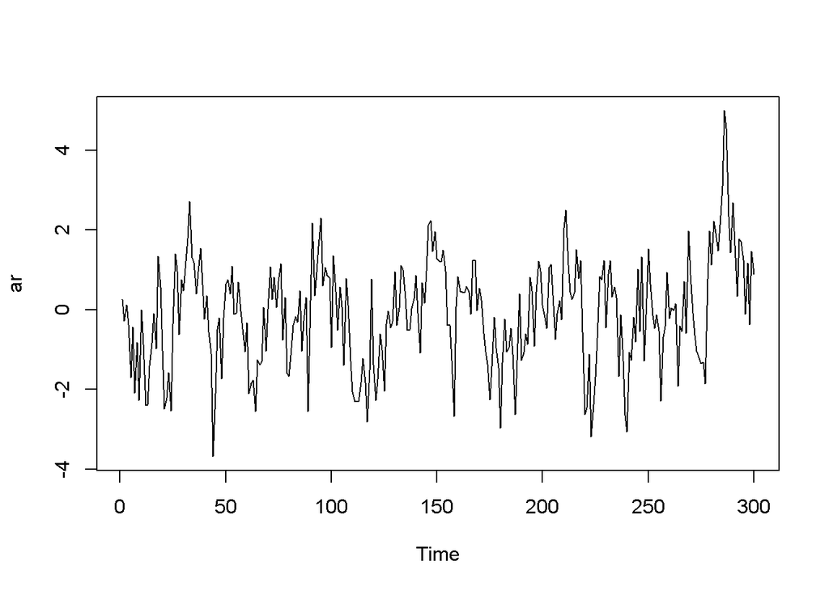

```r
ts.plot(ar)
```

Berdasarkan plot time series tersebut terlihat bahwa data AR(2) yang dibangkitkan cenderung stasioner pada rataan

### Plot ACF

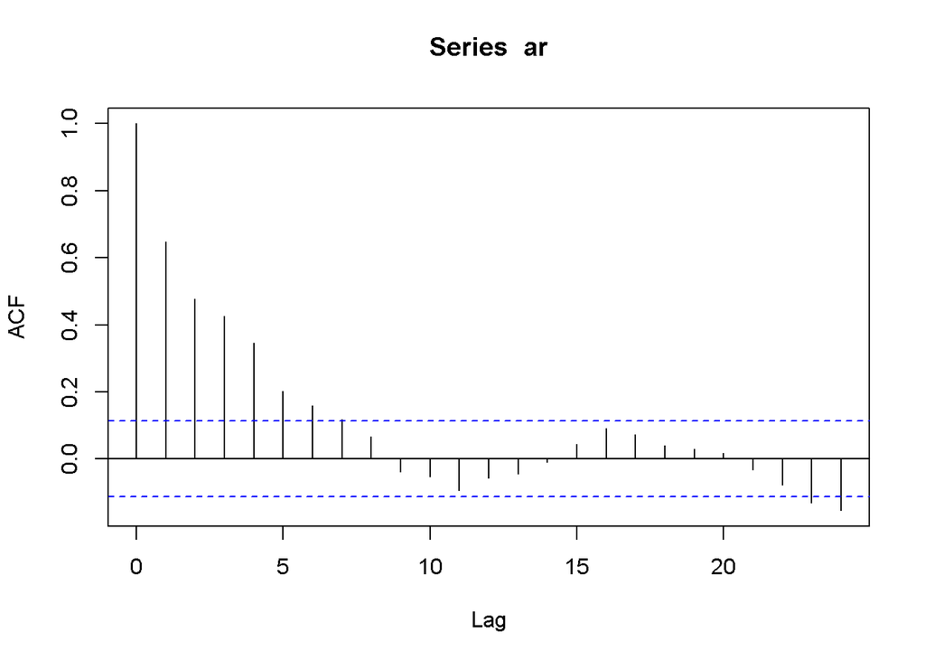

```r
acf(ar)
```

Plot ACF cenderung *tails off* dan cenderung membentuk pola grafik sinus

### Plot PACF

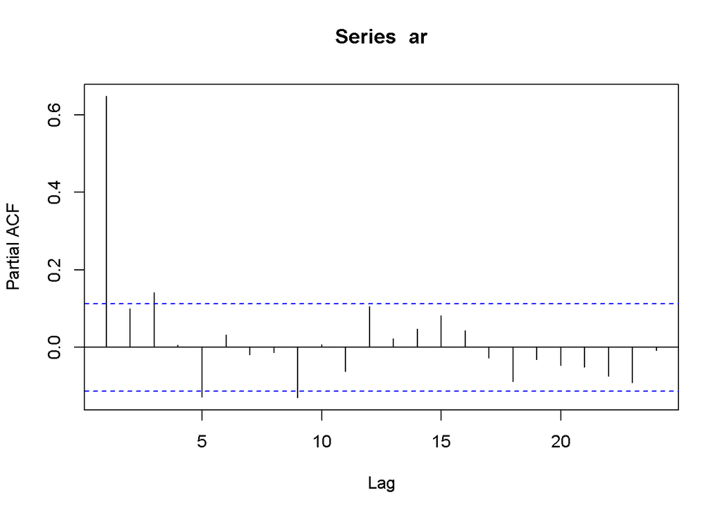

```r
pacf(ar)
```

### Plot EACF

```r
TSA::eacf(ar)
```

```
## AR/MA
##   0 1 2 3 4 5 6 7 8 9 10 11 12 13
## 0 x x x x x x x o o o o  o  o  o
## 1 x x o x x o o o x o o  o  o  o
## 2 x x o x o o o o o o o  o  o  o
## 3 o x o x o o o o o o o  o  o  o
## 4 o x x x o o o x o o o  o  o  o
## 5 x o x x o o o o o o o  o  o  o
## 6 x x o x x o o o o o o  o  o  o
## 7 x o o x x x o o o o o  o  o  o
```

Berdasarkan pola segitiga nol pada plot EACF, tidak terlihat bahwa segitiga nol berada pada ordo AR(2) dan ordo MA(0). Hal ini bisa dikarenakan EACF lebih cocok untuk ARMA dan bisa jadi juga dikarenakan nilai $\phi_1=0.5$ dan $\phi_2=0.2$ tidak terlalu besar sehingga EACF tertutup perubahan error.

### Scatterplot Antar Lag

#### Korelasi antara $Y_t$ dengan $Y_{t-1}$

```r
#Yt
yt_ar <- ar[-1]
yt_ar
```

```
##   [1] -0.275126268  0.119516321 -0.374616519 -1.706094859 -0.428341126
##   [6] -2.079192568 -0.820454197 -2.268717384 -0.009270767 -0.866936764
##  [11] -2.388574714 -2.380335899 -1.408264782 -0.838832955 -0.093480046
##  [16] -0.982270067  1.332232088  0.564877991 -1.020176269 -2.491054293
##  [21] -2.203832446 -1.579329298 -2.540151809 -0.359571062  1.400142642
##  [26]  0.972753841 -0.623637095  0.757841244  0.471529333  1.218860490
##  [31]  1.784283667  2.717341059  1.311513157  1.191774470  0.399716414
##  [36]  0.945938533  1.543930026  0.628389273 -0.232453702  0.352834066
##  [41] -0.561844230 -1.099232358 -3.678342756 -2.101777550 -0.502858135
##  [46] -0.197370244 -1.734739256 -0.206023617  0.650936145  0.747594092
##  [51]  0.395849274  1.091521322 -0.107962478 -0.079233561  0.685458999
##  [56] -0.032711796 -0.479476140 -1.050166358 -0.330700886 -2.107832510
##  [61] -1.835185337 -1.765212634 -2.542167375 -1.246161002 -1.376583578
##  [66] -1.299210625  0.061627639 -1.030290324  0.006876374  1.072202329
##  [71]  0.255336193  0.817218154  0.063029520  0.701369705  1.157924813
```

[output cut: 45 more lines]

```r
#Yt-1
yt_1_ar <- ar[-300]
yt_1_ar
```

```
##   [1]  0.253746487 -0.275126268  0.119516321 -0.374616519 -1.706094859
##   [6] -0.428341126 -2.079192568 -0.820454197 -2.268717384 -0.009270767
##  [11] -0.866936764 -2.388574714 -2.380335899 -1.408264782 -0.838832955
##  [16] -0.093480046 -0.982270067  1.332232088  0.564877991 -1.020176269
##  [21] -2.491054293 -2.203832446 -1.579329298 -2.540151809 -0.359571062
##  [26]  1.400142642  0.972753841 -0.623637095  0.757841244  0.471529333
##  [31]  1.218860490  1.784283667  2.717341059  1.311513157  1.191774470
##  [36]  0.399716414  0.945938533  1.543930026  0.628389273 -0.232453702
##  [41]  0.352834066 -0.561844230 -1.099232358 -3.678342756 -2.101777550
##  [46] -0.502858135 -0.197370244 -1.734739256 -0.206023617  0.650936145
##  [51]  0.747594092  0.395849274  1.091521322 -0.107962478 -0.079233561
##  [56]  0.685458999 -0.032711796 -0.479476140 -1.050166358 -0.330700886
##  [61] -2.107832510 -1.835185337 -1.765212634 -2.542167375 -1.246161002
##  [66] -1.376583578 -1.299210625  0.061627639 -1.030290324  0.006876374
##  [71]  1.072202329  0.255336193  0.817218154  0.063029520  0.701369705
```

[output cut: 45 more lines]

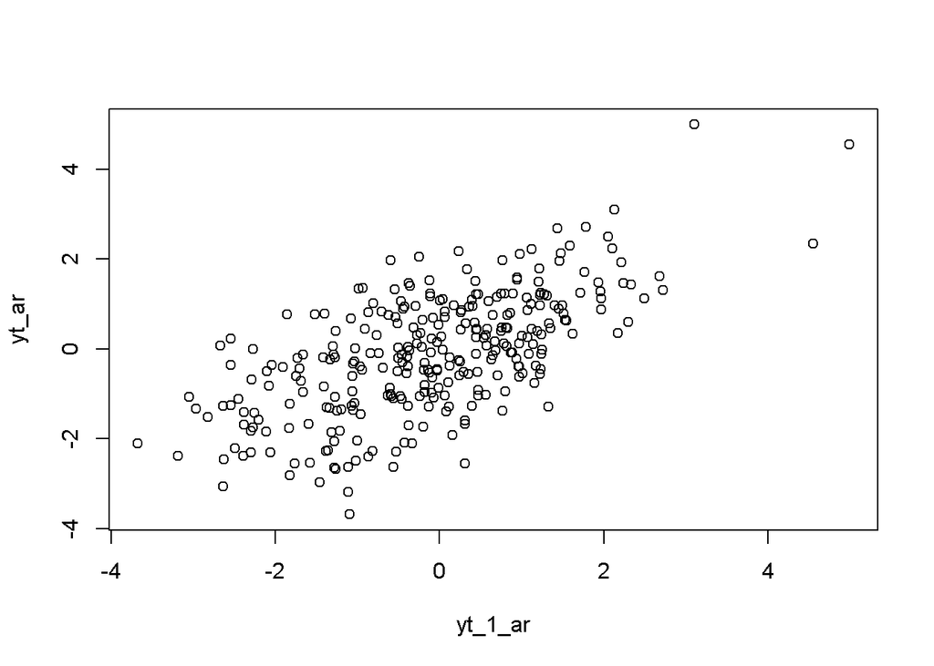

```r
plot(y=yt_ar,x=yt_1_ar)
```

Berdasarkan scatterplot tersebut, terlihat bahwa terdapat hubungan positif antara $Y_t$ dengan $Y_{t-1}$. Hal ini sesuai dengan teori yang ada

```r
cor(yt_ar,yt_1_ar)
```

```
## [1] 0.6485256
```

Korelasi antara $Y_t$ dengan $Y_{t-1}$ dari hasil simulasi mendekati perhitungan teoritis yaitu

$$\rho_1=\frac{\phi_1}{1-\phi_2}=\frac{0.5}{1-0.2}=0.62$$

#### Korelasi antara $Y_t$ dengan $Y_{t-2}$

```r
#Yt
yt_ar2 <- ar[-c(1,2)]
yt_ar2
```

```
##   [1]  0.119516321 -0.374616519 -1.706094859 -0.428341126 -2.079192568
##   [6] -0.820454197 -2.268717384 -0.009270767 -0.866936764 -2.388574714
##  [11] -2.380335899 -1.408264782 -0.838832955 -0.093480046 -0.982270067
##  [16]  1.332232088  0.564877991 -1.020176269 -2.491054293 -2.203832446
##  [21] -1.579329298 -2.540151809 -0.359571062  1.400142642  0.972753841
##  [26] -0.623637095  0.757841244  0.471529333  1.218860490  1.784283667
##  [31]  2.717341059  1.311513157  1.191774470  0.399716414  0.945938533
##  [36]  1.543930026  0.628389273 -0.232453702  0.352834066 -0.561844230
##  [41] -1.099232358 -3.678342756 -2.101777550 -0.502858135 -0.197370244
##  [46] -1.734739256 -0.206023617  0.650936145  0.747594092  0.395849274
##  [51]  1.091521322 -0.107962478 -0.079233561  0.685458999 -0.032711796
##  [56] -0.479476140 -1.050166358 -0.330700886 -2.107832510 -1.835185337
##  [61] -1.765212634 -2.542167375 -1.246161002 -1.376583578 -1.299210625
##  [66]  0.061627639 -1.030290324  0.006876374  1.072202329  0.255336193
##  [71]  0.817218154  0.063029520  0.701369705  1.157924813 -0.762925419
```

[output cut: 45 more lines]

```r
#Yt-2
yt_2_ar <- ar[-c(299,300)]
yt_2_ar
```

```
##   [1]  0.253746487 -0.275126268  0.119516321 -0.374616519 -1.706094859
##   [6] -0.428341126 -2.079192568 -0.820454197 -2.268717384 -0.009270767
##  [11] -0.866936764 -2.388574714 -2.380335899 -1.408264782 -0.838832955
##  [16] -0.093480046 -0.982270067  1.332232088  0.564877991 -1.020176269
##  [21] -2.491054293 -2.203832446 -1.579329298 -2.540151809 -0.359571062
##  [26]  1.400142642  0.972753841 -0.623637095  0.757841244  0.471529333
##  [31]  1.218860490  1.784283667  2.717341059  1.311513157  1.191774470
##  [36]  0.399716414  0.945938533  1.543930026  0.628389273 -0.232453702
##  [41]  0.352834066 -0.561844230 -1.099232358 -3.678342756 -2.101777550
##  [46] -0.502858135 -0.197370244 -1.734739256 -0.206023617  0.650936145
##  [51]  0.747594092  0.395849274  1.091521322 -0.107962478 -0.079233561
##  [56]  0.685458999 -0.032711796 -0.479476140 -1.050166358 -0.330700886
##  [61] -2.107832510 -1.835185337 -1.765212634 -2.542167375 -1.246161002
##  [66] -1.376583578 -1.299210625  0.061627639 -1.030290324  0.006876374
##  [71]  1.072202329  0.255336193  0.817218154  0.063029520  0.701369705
```

[output cut: 45 more lines]

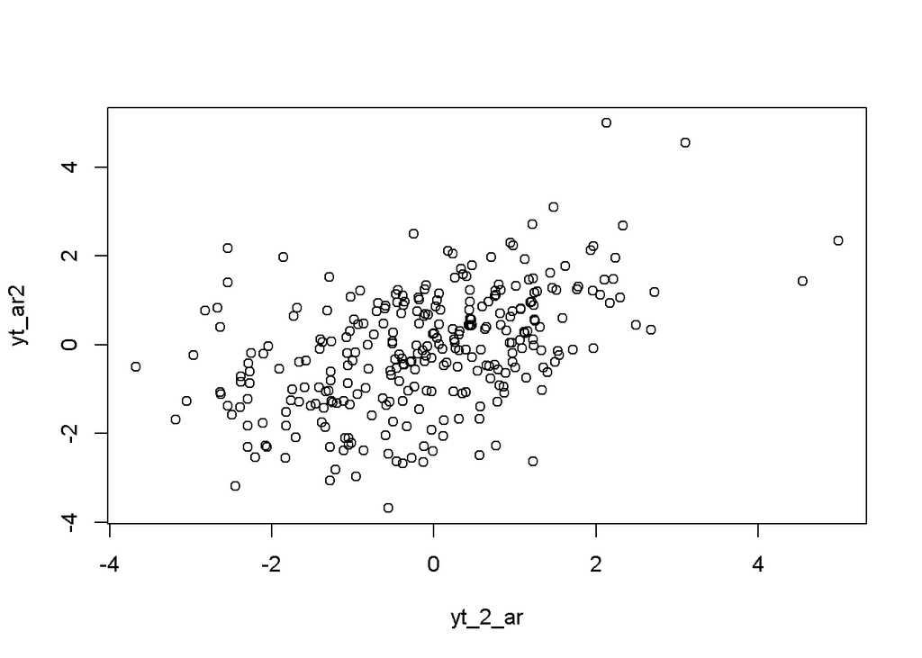

```r
plot(y=yt_ar2,x=yt_2_ar)
```

Berdasarkan scatterplot tersebut, terlihat bahwa terdapat hubungan positif antara $Y_t$ dengan $Y_{t-2}$. Hal ini sesuai dengan teori yang ada

```r
cor(yt_ar2,yt_2_ar)
```

```
## [1] 0.479665
```

Korelasi antara $Y_t$ dengan $Y_{t-2}$ dari hasil simulasi mendekati perhitungan teoritis yaitu

$$\rho_2=\phi_1\rho_1+\phi_2=0.5(0.62)+0.2=0.51$$
.

#### Korelasi antara $Y_t$ dengan $Y_{t-3}$

```r
#Yt
yt_ar3 <- ar[-c(1,2,3)]
yt_ar3
```

```
##   [1] -0.374616519 -1.706094859 -0.428341126 -2.079192568 -0.820454197
##   [6] -2.268717384 -0.009270767 -0.866936764 -2.388574714 -2.380335899
##  [11] -1.408264782 -0.838832955 -0.093480046 -0.982270067  1.332232088
##  [16]  0.564877991 -1.020176269 -2.491054293 -2.203832446 -1.579329298
##  [21] -2.540151809 -0.359571062  1.400142642  0.972753841 -0.623637095
##  [26]  0.757841244  0.471529333  1.218860490  1.784283667  2.717341059
##  [31]  1.311513157  1.191774470  0.399716414  0.945938533  1.543930026
##  [36]  0.628389273 -0.232453702  0.352834066 -0.561844230 -1.099232358
##  [41] -3.678342756 -2.101777550 -0.502858135 -0.197370244 -1.734739256
##  [46] -0.206023617  0.650936145  0.747594092  0.395849274  1.091521322
##  [51] -0.107962478 -0.079233561  0.685458999 -0.032711796 -0.479476140
##  [56] -1.050166358 -0.330700886 -2.107832510 -1.835185337 -1.765212634
##  [61] -2.542167375 -1.246161002 -1.376583578 -1.299210625  0.061627639
##  [66] -1.030290324  0.006876374  1.072202329  0.255336193  0.817218154
##  [71]  0.063029520  0.701369705  1.157924813 -0.762925419  0.307161268
```

[output cut: 45 more lines]

```r
#Yt-3
yt_3_ar <- ar[-c(298,299,300)]
yt_3_ar
```

```
##   [1]  0.253746487 -0.275126268  0.119516321 -0.374616519 -1.706094859
##   [6] -0.428341126 -2.079192568 -0.820454197 -2.268717384 -0.009270767
##  [11] -0.866936764 -2.388574714 -2.380335899 -1.408264782 -0.838832955
##  [16] -0.093480046 -0.982270067  1.332232088  0.564877991 -1.020176269
##  [21] -2.491054293 -2.203832446 -1.579329298 -2.540151809 -0.359571062
##  [26]  1.400142642  0.972753841 -0.623637095  0.757841244  0.471529333
##  [31]  1.218860490  1.784283667  2.717341059  1.311513157  1.191774470
##  [36]  0.399716414  0.945938533  1.543930026  0.628389273 -0.232453702
##  [41]  0.352834066 -0.561844230 -1.099232358 -3.678342756 -2.101777550
##  [46] -0.502858135 -0.197370244 -1.734739256 -0.206023617  0.650936145
##  [51]  0.747594092  0.395849274  1.091521322 -0.107962478 -0.079233561
##  [56]  0.685458999 -0.032711796 -0.479476140 -1.050166358 -0.330700886
##  [61] -2.107832510 -1.835185337 -1.765212634 -2.542167375 -1.246161002
##  [66] -1.376583578 -1.299210625  0.061627639 -1.030290324  0.006876374
##  [71]  1.072202329  0.255336193  0.817218154  0.063029520  0.701369705
```

[output cut: 45 more lines]

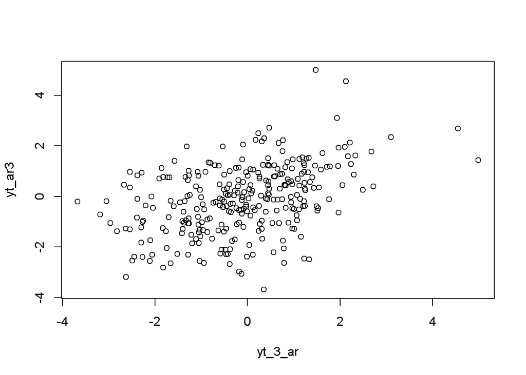

```r
plot(y=yt_ar3,x=yt_3_ar)
```

Berdasarkan scatterplot tersebut, terlihat bahwa terdapat hubungan positif antara $Y_t$ dengan $Y_{t-3}$. Hal ini sesuai dengan teori yang ada

```r
cor(yt_ar3,yt_3_ar)
```

```
## [1] 0.4265314
```

Korelasi antara $Y_t$ dengan $Y_{t-3}$ dari hasil simulasi mendekati perhitungan teoritis yaitu

$$\rho_2=\phi_1\rho_2+\phi_2\rho_1=0.5(0.51)+0.2(0.62)=0.38$$
.

## Fungsi pembangkitan ARMA

$$y_{t} = c + \sum_{i=1}^p \phi_{i}y_{t-i} + \sum_{j=1}^q e_{t-j}+ e_{t}$$

```r
arma.sim <- function(n, macoef, arcoef){
  manum <- length(macoef)
  arnum <- length(arcoef)
  stopifnot(manum < n & arnum < n)

  wn <- rnorm(n, sd = 0.5)
  init <- max(manum, arnum)

  arma <- wn[1:init]
  for(i in {init+1}:n){
   mastart <- i - manum
   maend <- i-1
   arstart <- i - arnum
   arend <- i-1
   arma[i] <- sum(arcoef * arma[arstart:arend]) + sum(macoef * wn[mastart:maend])  + wn[i]
   }
  return(arma)
}
```

```r
set.seed(1070)

phi1 = 0.5
phi2 = 0.2
theta1 = 0.4
theta2 = 0.6

y.arma <- numeric(n)
y.arma[1] <- wn[1]
y.arma[2] <- phi1*y.arma[1] + wn[2] + theta1*wn[1]

for (i in 3:n){
  y.arma[i] = phi1*y.arma[i-1] + phi2*y.arma[i-2] + theta1*wn[i-1] + theta2*wn[i-2] + wn[i]
}
y.arma
```

```
##   [1]  0.2537464871 -0.1736276728  0.1617137061 -0.4918857510 -1.7842316736
##   [6] -1.3355489802 -3.2741859332 -1.9091358991 -3.8444146035 -1.4090302391
##  [11] -2.2318755017 -2.7409118799 -3.8559278426 -3.7935439694 -2.8303404070
##  [16] -1.2739720968 -1.5229618583  0.8832360338  0.5084087859  0.0051141801
##  [21] -2.5601980061 -3.8123599247 -3.9554948519 -4.4941829954 -2.3232293645
##  [26] -0.2677768679  1.3170682602  0.6055500264  1.0920387100  0.4004835734
##  [31]  1.8621769699  2.5547454632  4.1623708197  3.4690197808  3.3467843676
##  [36]  1.6633340958  1.8208897805  2.1621352879  1.8135244039  0.9452600228
##  [41]  0.6368861489 -0.5601828256 -1.1122696106 -4.4551422378 -4.2326540670
##  [46] -3.5505748087 -1.6595800277 -2.1154022344 -1.0183414660 -0.4723168552
##  [51]  0.8843543794  1.0854485975  1.6984174869  0.5661556155  0.5324942413
##  [56]  0.5889880884  0.1939316676 -0.0812854582 -1.2615838916 -1.0384531131
##  [61] -2.8702126797 -2.8767388726 -3.7639862752 -4.3493636311 -3.3221555327
##  [66] -3.4003484042 -2.5975406574 -1.2840067578 -1.7851656430 -0.3682631724
##  [71]  0.4567786843  0.6883429484  1.5626740286  0.5431184969  1.2169124050
```

[output cut: 45 more lines]

Pembangkitan ARMA(p,q) juga dapat dilakukan dengan fungsi `arima.sim` sebagai berikut.

```r
arma22 <- arima.sim(list(order=c(2,0,2), ar = c(0.5,0.2), ma = c(0.4,0.6)), n=300)
arma22
```

```
## Time Series:
## Start = 1
## End = 300
## Frequency = 1
##   [1]  0.6056187577  1.0920911072  0.4005235183  1.8622074218  2.5547686781
##   [6]  4.1623885176  3.4690332727  3.3467946531  1.6633419370  1.8208957582
##  [11]  2.1621398450  1.8135278780  0.9452626712  0.6368881680 -0.5601812864
##  [16] -1.1122684372 -4.4551413433 -4.2326533850 -3.5505742888 -1.6595796313
##  [21] -2.1154019323 -1.0183412356 -0.4723166796  0.8843545133  1.0854486996
##  [26]  1.6984175647  0.5661556748  0.5324942865  0.5889881229  0.1939316939
##  [31] -0.0812854382 -1.2615838763 -1.0384531015 -2.8702126708 -2.8767388658
##  [36] -3.7639862701 -4.3493636272 -3.3221555297 -3.4003484019 -2.5975406557
##  [41] -1.2840067565 -1.7851656419 -0.3682631716  0.4567786849  0.6883429489
##  [46]  1.5626740290  0.5431184972  1.2169124052  1.4762904064  0.1210663290
##  [51]  0.6967459877 -1.9279351337 -2.1173367764 -2.5878869784 -1.7759151721
```

[output cut: 49 more lines]

## Karakteristik ARMA(2,2)

### Plot Time Series

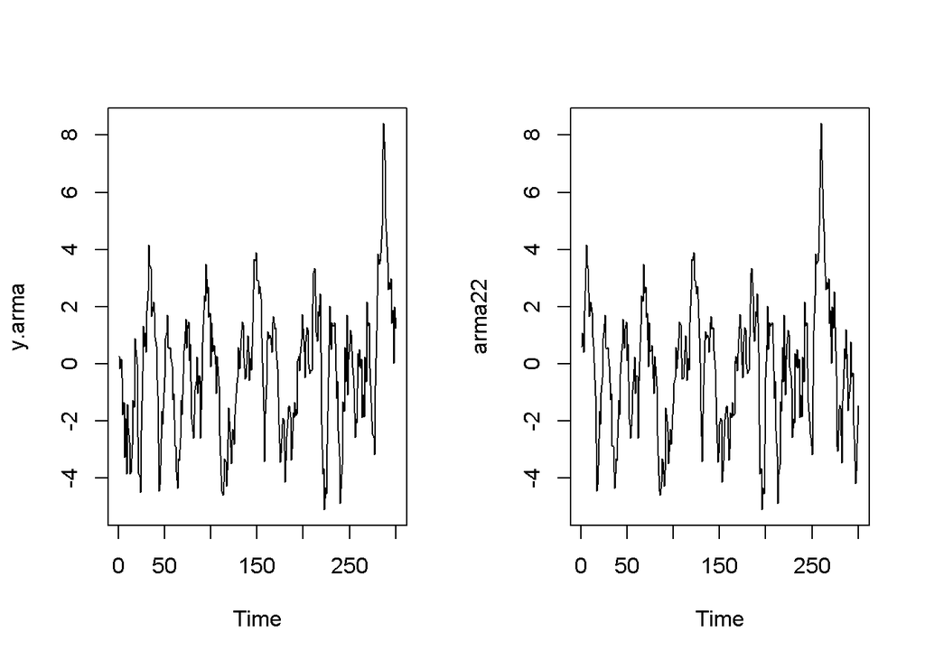

```r
par(mfrow = c(1, 2))
ts.plot(y.arma)
ts.plot(arma22)
```

```r
par(mfrow = c(1, 1))
```

Berdasarkan plot time series tersebut, terlihat bahwa model ARMA(2,2) cenderung stasioner dalam rataan

### Plot ACF

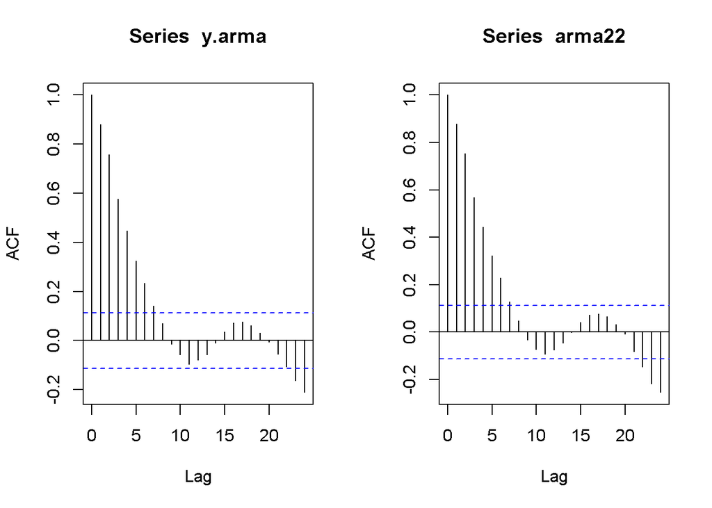

```r
par(mfrow = c(1, 2))
acf(y.arma)
acf(arma22)
```

```r
par(mfrow = c(1, 1))
```

Berdasarkan plot ACF tersebut, terlihat bahwa model ARMA(2,2) hasil simulasi memiliki plot ACF yang *tails off*, sesuai dengan teori yang ada

### Plot PACF

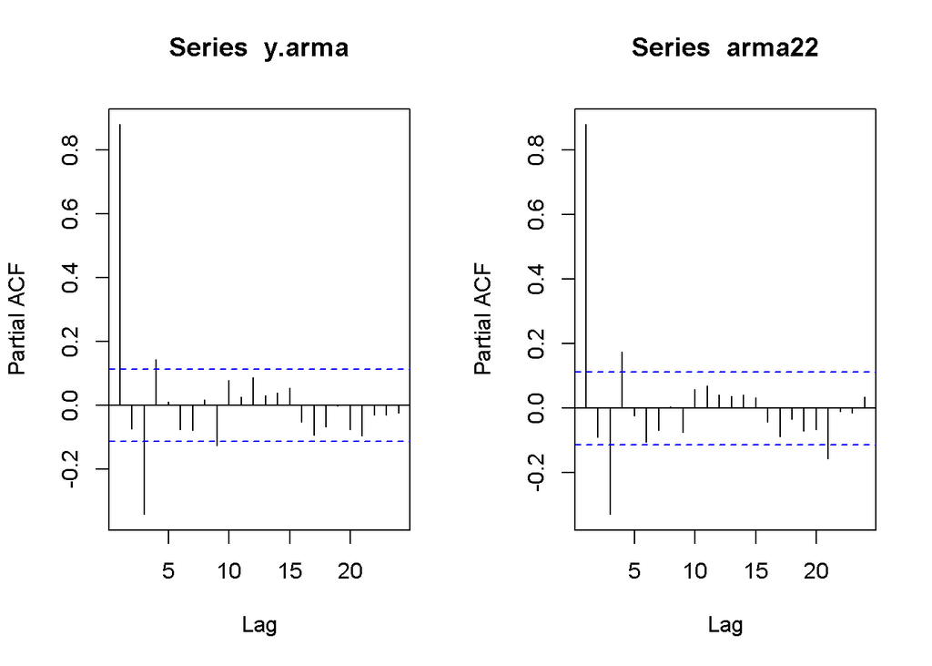

```r
par(mfrow = c(1, 2))
pacf(y.arma)
pacf(arma22)
```

```r
par(mfrow = c(1, 1))
```

Berdasarkan plot PACF tersebut, terlihat bahwa model ARMA(2,2) hasil simulasi memiliki plot PACF yang *tails off*, sesuai dengan teori

### Plot EACF

```r
TSA::eacf(y.arma)
```

```
## AR/MA
##   0 1 2 3 4 5 6 7 8 9 10 11 12 13
## 0 x x x x x x x o o o o  o  o  o
## 1 o x o o o x o o o o x  o  o  o
## 2 x x x o o x o x x o x  o  o  o
## 3 x x x x o o o x o o o  o  o  o
## 4 o x o x o o o o o o o  o  o  o
## 5 x x o x o o o o o o o  o  o  o
## 6 x x o o o o x o o o o  o  o  o
## 7 x x x o x o o x o o o  o  o  o
```

```r
TSA::eacf(arma22)
```

```
## AR/MA
##   0 1 2 3 4 5 6 7 8 9 10 11 12 13
## 0 x x x x x x x o o o o  o  o  o
## 1 o x o x o x o o o o x  o  o  o
## 2 x x x x o x o x x o o  o  o  o
## 3 x x x o o o o x o o o  o  o  o
## 4 x x x x x o o x o o o  o  o  o
## 5 x x o x x o o x o o o  o  o  o
## 6 x x o o x o x o o o o  o  o  o
## 7 o x o x x o o x o o o  o  o  o
```

Berdasarkan pola segitiga nol pada plot EACF, tidak terlihat bahwa segitiga nol berada pada ordo AR(2) dan ordo MA(2). Hal ini mungkin terjadi karena ukuran sampel yang terbatas, sehingga EACF tidak bisa menampilkan pola ARMA(2,2) dengan jelas.

### Scatterplot Antar Lag

#### Korelasi antara $Y_t$ dengan $Y_{t-1}$

```r
#Yt
yt_arma <- arma22[-1]
yt_arma
```

```
##   [1]  1.0920911072  0.4005235183  1.8622074218  2.5547686781  4.1623885176
##   [6]  3.4690332727  3.3467946531  1.6633419370  1.8208957582  2.1621398450
##  [11]  1.8135278780  0.9452626712  0.6368881680 -0.5601812864 -1.1122684372
##  [16] -4.4551413433 -4.2326533850 -3.5505742888 -1.6595796313 -2.1154019323
##  [21] -1.0183412356 -0.4723166796  0.8843545133  1.0854486996  1.6984175647
##  [26]  0.5661556748  0.5324942865  0.5889881229  0.1939316939 -0.0812854382
##  [31] -1.2615838763 -1.0384531015 -2.8702126708 -2.8767388658 -3.7639862701
##  [36] -4.3493636272 -3.3221555297 -3.4003484019 -2.5975406557 -1.2840067565
##  [41] -1.7851656419 -0.3682631716  0.4567786849  0.6883429489  1.5626740290
##  [46]  0.5431184972  1.2169124052  1.4762904064  0.1210663290  0.6967459877
##  [51] -1.9279351337 -2.1173367764 -2.5878869784 -1.7759151721 -0.9145728816
##  [56] -0.6210539015  0.2376446983 -1.0374019519 -0.4112312247 -0.4271214636
##  [61] -2.5904816046 -0.6030640662  0.7344836264  1.3650739819  2.3849460972
##  [66]  2.1767971177  3.4972682218  2.4687482536  2.6870368717  1.6434113469
##  [71]  1.7835077282 -0.1049948082  1.4533355269  0.4381586533  0.4845938907
```

[output cut: 45 more lines]

```r
#Yt-1
yt_1_arma <- arma22[-300]
yt_1_arma
```

```
##   [1]  0.6056187577  1.0920911072  0.4005235183  1.8622074218  2.5547686781
##   [6]  4.1623885176  3.4690332727  3.3467946531  1.6633419370  1.8208957582
##  [11]  2.1621398450  1.8135278780  0.9452626712  0.6368881680 -0.5601812864
##  [16] -1.1122684372 -4.4551413433 -4.2326533850 -3.5505742888 -1.6595796313
##  [21] -2.1154019323 -1.0183412356 -0.4723166796  0.8843545133  1.0854486996
##  [26]  1.6984175647  0.5661556748  0.5324942865  0.5889881229  0.1939316939
##  [31] -0.0812854382 -1.2615838763 -1.0384531015 -2.8702126708 -2.8767388658
##  [36] -3.7639862701 -4.3493636272 -3.3221555297 -3.4003484019 -2.5975406557
##  [41] -1.2840067565 -1.7851656419 -0.3682631716  0.4567786849  0.6883429489
##  [46]  1.5626740290  0.5431184972  1.2169124052  1.4762904064  0.1210663290
##  [51]  0.6967459877 -1.9279351337 -2.1173367764 -2.5878869784 -1.7759151721
##  [56] -0.9145728816 -0.6210539015  0.2376446983 -1.0374019519 -0.4112312247
##  [61] -0.4271214636 -2.5904816046 -0.6030640662  0.7344836264  1.3650739819
##  [66]  2.3849460972  2.1767971177  3.4972682218  2.4687482536  2.6870368717
##  [71]  1.6434113469  1.7835077282 -0.1049948082  1.4533355269  0.4381586533
```

[output cut: 45 more lines]

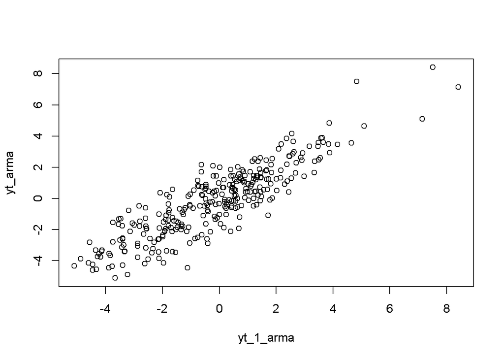

```r
plot(y=yt_arma,x=yt_1_arma)
```

Berdasarkan scatterplot tersebut, terlihat bahwa terdapat hubungan positif antara $Y_t$ dengan $Y_{t-1}$. Hal ini sesuai dengan teori yang ada

```r
cor(yt_arma,yt_1_arma)
```

```
## [1] 0.879793
```

Korelasi antara $Y_t$ dengan $Y_{t-1}$ dari hasil simulasi mendekati perhitungan teoritis.
$$\rho_k = \frac{(1-\theta
\phi)(\phi-\theta)}{1-2\theta\phi+\theta^2}\phi^{k-1} \:untuk \:k\ge1$$

#### Korelasi antara $Y_t$ dengan $Y_{t-2}$

```r
#Yt
yt_arma2 <- arma22[-c(1,2)]
yt_arma2
```

```
##   [1]  0.4005235183  1.8622074218  2.5547686781  4.1623885176  3.4690332727
##   [6]  3.3467946531  1.6633419370  1.8208957582  2.1621398450  1.8135278780
##  [11]  0.9452626712  0.6368881680 -0.5601812864 -1.1122684372 -4.4551413433
##  [16] -4.2326533850 -3.5505742888 -1.6595796313 -2.1154019323 -1.0183412356
##  [21] -0.4723166796  0.8843545133  1.0854486996  1.6984175647  0.5661556748
##  [26]  0.5324942865  0.5889881229  0.1939316939 -0.0812854382 -1.2615838763
##  [31] -1.0384531015 -2.8702126708 -2.8767388658 -3.7639862701 -4.3493636272
##  [36] -3.3221555297 -3.4003484019 -2.5975406557 -1.2840067565 -1.7851656419
##  [41] -0.3682631716  0.4567786849  0.6883429489  1.5626740290  0.5431184972
##  [46]  1.2169124052  1.4762904064  0.1210663290  0.6967459877 -1.9279351337
##  [51] -2.1173367764 -2.5878869784 -1.7759151721 -0.9145728816 -0.6210539015
##  [56]  0.2376446983 -1.0374019519 -0.4112312247 -0.4271214636 -2.5904816046
##  [61] -0.6030640662  0.7344836264  1.3650739819  2.3849460972  2.1767971177
##  [66]  3.4972682218  2.4687482536  2.6870368717  1.6434113469  1.7835077282
##  [71] -0.1049948082  1.4533355269  0.4381586533  0.4845938907  0.6439873399
```

[output cut: 45 more lines]

```r
#Yt-2
yt_2_arma <- arma22[-c(299,300)]
yt_2_arma
```

```
##   [1]  0.6056187577  1.0920911072  0.4005235183  1.8622074218  2.5547686781
##   [6]  4.1623885176  3.4690332727  3.3467946531  1.6633419370  1.8208957582
##  [11]  2.1621398450  1.8135278780  0.9452626712  0.6368881680 -0.5601812864
##  [16] -1.1122684372 -4.4551413433 -4.2326533850 -3.5505742888 -1.6595796313
##  [21] -2.1154019323 -1.0183412356 -0.4723166796  0.8843545133  1.0854486996
##  [26]  1.6984175647  0.5661556748  0.5324942865  0.5889881229  0.1939316939
##  [31] -0.0812854382 -1.2615838763 -1.0384531015 -2.8702126708 -2.8767388658
##  [36] -3.7639862701 -4.3493636272 -3.3221555297 -3.4003484019 -2.5975406557
##  [41] -1.2840067565 -1.7851656419 -0.3682631716  0.4567786849  0.6883429489
##  [46]  1.5626740290  0.5431184972  1.2169124052  1.4762904064  0.1210663290
##  [51]  0.6967459877 -1.9279351337 -2.1173367764 -2.5878869784 -1.7759151721
##  [56] -0.9145728816 -0.6210539015  0.2376446983 -1.0374019519 -0.4112312247
##  [61] -0.4271214636 -2.5904816046 -0.6030640662  0.7344836264  1.3650739819
##  [66]  2.3849460972  2.1767971177  3.4972682218  2.4687482536  2.6870368717
##  [71]  1.6434113469  1.7835077282 -0.1049948082  1.4533355269  0.4381586533
```

[output cut: 45 more lines]

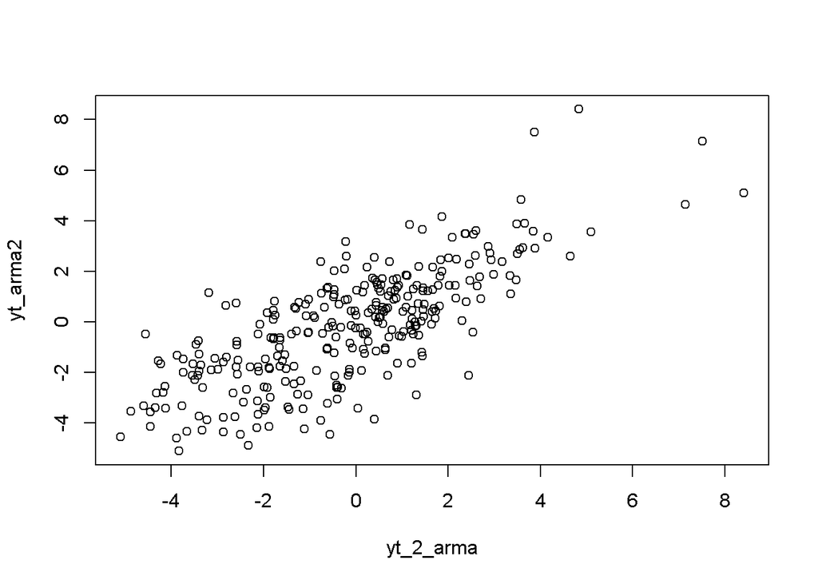

```r
plot(y=yt_arma2,x=yt_2_arma)
```

```r
cor(yt_arma2,yt_2_arma)
```

```
## [1] 0.7552331
```

```r
#Yt
yt_arma3 <- arma22[-c(1,2,3)]
yt_arma3
```

```
##   [1]  1.8622074218  2.5547686781  4.1623885176  3.4690332727  3.3467946531
##   [6]  1.6633419370  1.8208957582  2.1621398450  1.8135278780  0.9452626712
##  [11]  0.6368881680 -0.5601812864 -1.1122684372 -4.4551413433 -4.2326533850
##  [16] -3.5505742888 -1.6595796313 -2.1154019323 -1.0183412356 -0.4723166796
##  [21]  0.8843545133  1.0854486996  1.6984175647  0.5661556748  0.5324942865
##  [26]  0.5889881229  0.1939316939 -0.0812854382 -1.2615838763 -1.0384531015
##  [31] -2.8702126708 -2.8767388658 -3.7639862701 -4.3493636272 -3.3221555297
##  [36] -3.4003484019 -2.5975406557 -1.2840067565 -1.7851656419 -0.3682631716
##  [41]  0.4567786849  0.6883429489  1.5626740290  0.5431184972  1.2169124052
##  [46]  1.4762904064  0.1210663290  0.6967459877 -1.9279351337 -2.1173367764
##  [51] -2.5878869784 -1.7759151721 -0.9145728816 -0.6210539015  0.2376446983
##  [56] -1.0374019519 -0.4112312247 -0.4271214636 -2.5904816046 -0.6030640662
##  [61]  0.7344836264  1.3650739819  2.3849460972  2.1767971177  3.4972682218
##  [66]  2.4687482536  2.6870368717  1.6434113469  1.7835077282 -0.1049948082
##  [71]  1.4533355269  0.4381586533  0.4845938907  0.6439873399 -0.0003705921
```

[output cut: 45 more lines]

```r
#Yt-3
yt_3_arma <- arma22[-c(298,299,300)]
yt_3_arma
```

```
##   [1]  0.6056187577  1.0920911072  0.4005235183  1.8622074218  2.5547686781
##   [6]  4.1623885176  3.4690332727  3.3467946531  1.6633419370  1.8208957582
##  [11]  2.1621398450  1.8135278780  0.9452626712  0.6368881680 -0.5601812864
##  [16] -1.1122684372 -4.4551413433 -4.2326533850 -3.5505742888 -1.6595796313
##  [21] -2.1154019323 -1.0183412356 -0.4723166796  0.8843545133  1.0854486996
##  [26]  1.6984175647  0.5661556748  0.5324942865  0.5889881229  0.1939316939
##  [31] -0.0812854382 -1.2615838763 -1.0384531015 -2.8702126708 -2.8767388658
##  [36] -3.7639862701 -4.3493636272 -3.3221555297 -3.4003484019 -2.5975406557
##  [41] -1.2840067565 -1.7851656419 -0.3682631716  0.4567786849  0.6883429489
##  [46]  1.5626740290  0.5431184972  1.2169124052  1.4762904064  0.1210663290
##  [51]  0.6967459877 -1.9279351337 -2.1173367764 -2.5878869784 -1.7759151721
##  [56] -0.9145728816 -0.6210539015  0.2376446983 -1.0374019519 -0.4112312247
##  [61] -0.4271214636 -2.5904816046 -0.6030640662  0.7344836264  1.3650739819
##  [66]  2.3849460972  2.1767971177  3.4972682218  2.4687482536  2.6870368717
##  [71]  1.6434113469  1.7835077282 -0.1049948082  1.4533355269  0.4381586533
```

[output cut: 45 more lines]

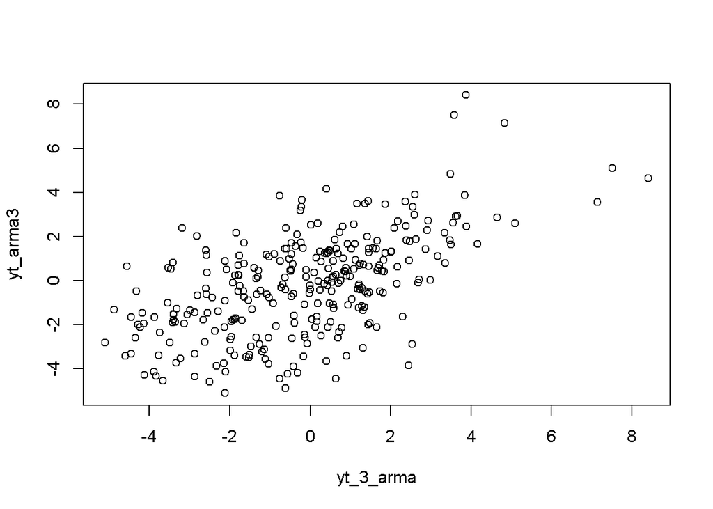

```r
plot(y=yt_arma3,x=yt_3_arma)
```

```r
cor(yt_arma3,yt_3_arma)
```

```
## [1] 0.5726778
```